# titanic SVM

## Read data and change its data type

```r
data <- read.csv("titanicTrain.csv")
# 去除NA
# 整理資料格式
data <- data[1:1000,]
sapply(data, function(x) {sum(is.na(x))})
```

```
##    pclass  survived      name       sex       age     sibsp     parch
##         0         0         0         0       139         0         0
##    ticket      fare     cabin  embarked      boat      body home.dest
##         0         0         0         0         0       905         0
```

```r
data <- subset(data, select = -body)
data <- data[is.na(data$age)!=TRUE,]
data$fs <- as.integer(data$parch)+as.integer(data$sibsp)+1

data$boat <- as.character(data$boat)
data$survived <- as.factor(data$survived)
data$pclass <- as.factor(data$pclass)
data$sibsp <- as.factor(data$sibsp)
data$parch <- as.factor(data$parch)
data$fs <- as.factor(data$fs)
library(knitr)
kable(summary(data))
```

|  | pclass | survived | name | sex | age | sibsp | parch | ticket | fare | cabin | embarked | boat | home.dest | fs |
| --- | --- | --- | --- | --- | --- | --- | --- | --- | --- | --- | --- | --- | --- | --- |
|  | 1:284 | 0:480 | Connolly, Miss. Kate : 2 | : 0 | Min. : 0.1667 | 0:554 | 0:635 | CA 2144 : 8 | Min. : 0.000 | :599 | : 2 | Length:861 | :179 | 1 :475 |
|  | 2:261 | 1:381 | Kelly, Mr. James : 2 | female:331 | 1st Qu.:22.0000 | 1:248 | 1:125 | 347077 : 7 | 1st Qu.: 9.688 | C23 C25 C27 : 6 | C:189 | Class :character | New York, NY : 55 | 2 :185 |
|  | 3:316 | NA | Abbing, Mr. Anthony : 1 | male :530 | Median :29.0000 | 2: 34 | 2: 85 | 347082 : 7 | Median : 21.000 | B57 B59 B63 B66: 5 | Q: 41 | Mode :character | London : 14 | 3 :120 |
|  | NA | NA | Abbott, Master. Eugene Joseph : 1 | NA | Mean :31.0842 | 3: 7 | 3: 8 | PC 17608 : 7 | Mean : 41.756 | B96 B98 : 4 | S:629 | NA | Montreal, PQ : 10 | 4 : 38 |
|  | NA | NA | Abbott, Mr. Rossmore Edward : 1 | NA | 3rd Qu.:40.0000 | 4: 12 | 4: 2 | S.O.C. 14879: 7 | 3rd Qu.: 49.500 | C22 C26 : 4 | NA | NA | Cornwall / Akron, OH : 9 | 7 : 16 |
|  | NA | NA | Abbott, Mrs. Stanton (Rosa Hunt): 1 | NA | Max. :80.0000 | 5: 6 | 5: 4 | 113781 : 6 | Max. :512.329 | C78 : 4 | NA | NA | Wiltshire, England Niagara Falls, NY: 8 | 5 : 12 |
|  | NA | NA | (Other) :853 | NA | NA | NA | 6: 2 | (Other) :819 | NA | (Other) :239 | NA | NA | (Other) :586 | (Other): 15 |

Use EDA to analyze the data.

## Summary:

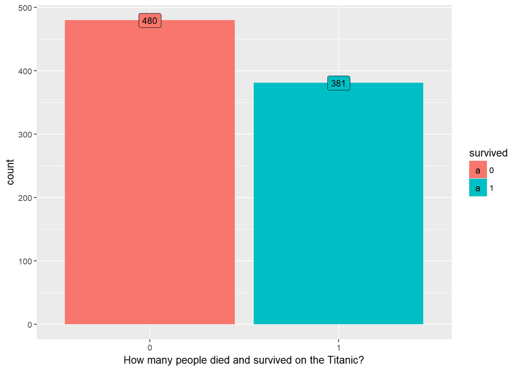

```r
# EDA
library(ggplot2)

library(gridExtra)

ggplot(data, aes(x = survived, fill = survived)) +
  geom_bar(stat='count', position='dodge') +
  labs(x = 'How many people died and survived on the Titanic?') +
  geom_label(stat='count',aes(label=..count..), size=3) +
  theme_grey(base_size = 10)
```

## 性別與艙等影響

性別和艙等的EDA分析 發現class1和2女性活下來的比例相當高，而class2和3男性活下來的比例最低

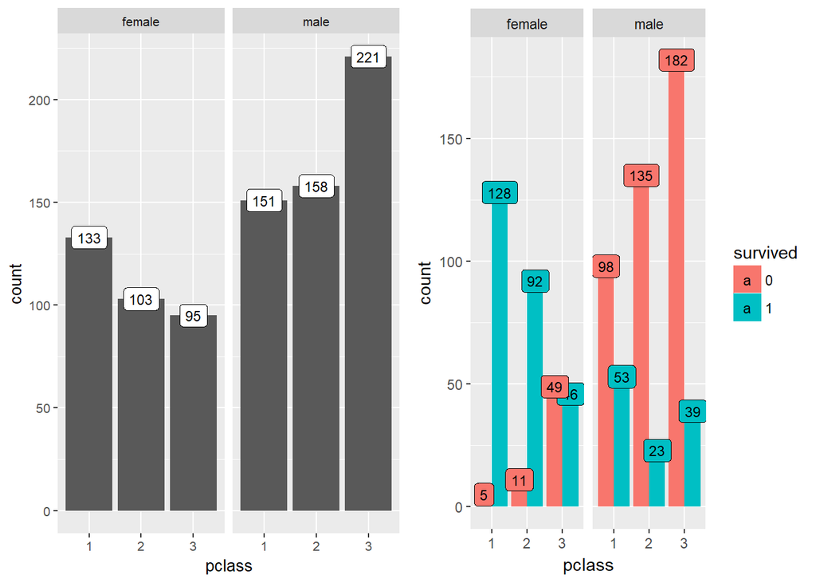

```r
#------- gender/sex-----------
b1 <- ggplot(data, aes(x = pclass)) +
  geom_bar(stat='count', position='dodge') +
  geom_label(stat='count',aes(label=..count..), size=3) +
  facet_grid(.~sex) +
  theme_grey(base_size = 10)

b2 <-
  ggplot(data, aes(x = pclass, fill = survived)) +
  geom_bar(stat='count', position='dodge') +
  geom_label(stat='count',aes(label=..count..), size=3, position = position_dodge(0.9)) +
  labs(x = 'pclass', y= "count") + facet_grid(.~sex) +
  theme(legend.position="none") + theme_grey()



# -----------pclass and sex-------------
### ----------class1.2女性活下來的比例相當高，class2.3男性活下來的比例最低
b3 <-
  ggplot(data, aes(x = pclass, fill = survived)) +
  geom_bar(stat='count', position='fill') +
  labs(x = 'pclass', y= "Percent") + facet_grid(.~sex) +
  theme(legend.position="none") + theme_grey()



grid.arrange(b1,b2,nrow=1)
```

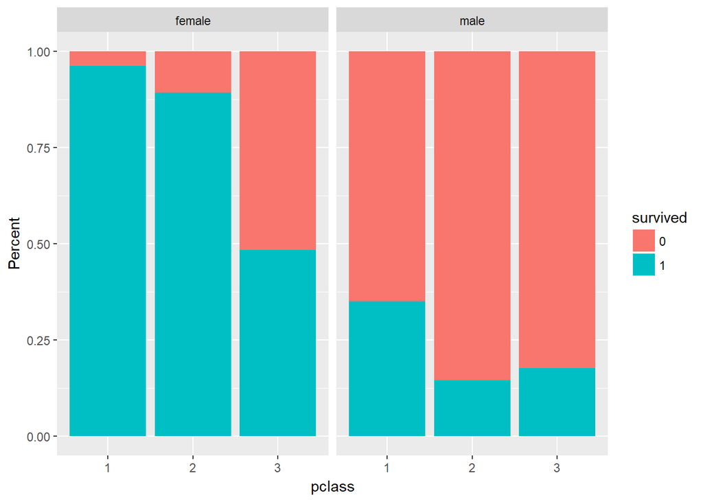

```r
b3
```

## 艙等

而單就艙等來評估的話，雖然各艙等的人數並無明顯差距，1等艙的旅客存活人數佔多數，而3等艙的旅客死亡人數則佔多數，2等艙則是較無明顯區別

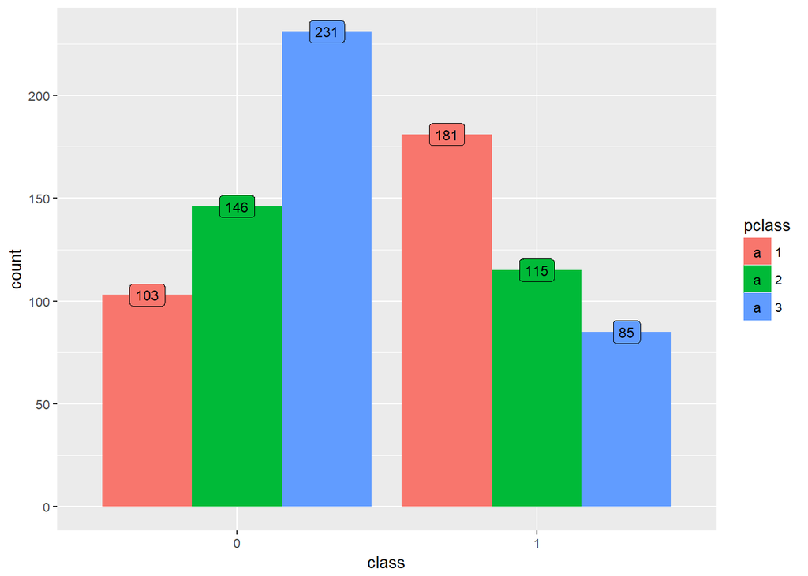

```r
#------ pclass ----------
ggplot(data, aes(x = survived, fill = pclass)) +
  geom_bar(stat='count', position='dodge') +
  geom_label(stat='count',aes(label=..count..), size=3, position=position_dodge(0.9)) +
  labs(x = 'class') +
  theme_grey(base_size = 10)
```

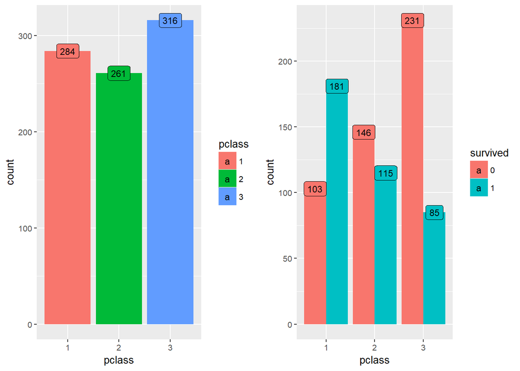

```r
b1 <- ggplot(data, aes(x = pclass, fill = pclass)) +
  geom_bar(stat='count', position='dodge') +
  geom_label(stat='count',aes(label=..count..), size=3) +
  theme_grey(base_size = 10)

b2 <-
  ggplot(data, aes(x = pclass, fill = survived)) +
  geom_bar(stat='count', position='dodge') +
  geom_label(stat='count',aes(label=..count..), size=3, position=position_dodge(0.9)) +
  theme_grey(base_size = 10)
grid.arrange(b1,b2, nrow=1)
```

## 性別與兄弟姊妹的影響

```r
#-----sibsp-----------

length(data$age[data$survived==1 & data$sibsp!=0 & data$parch!=0& data$sex=="female"])/length(data$age[data$survived==1 & data$sibsp!=0 & data$parch!=0])
```

```
## [1] 0.7228916
```

```r
length(data$age[data$survived==0 & data$sibsp!=0 & data$parch!=0& data$sex=="male"])/length(data$age[data$survived==0 & data$sibsp!=0 & data$parch!=0])
```

```
## [1] 0.6875
```

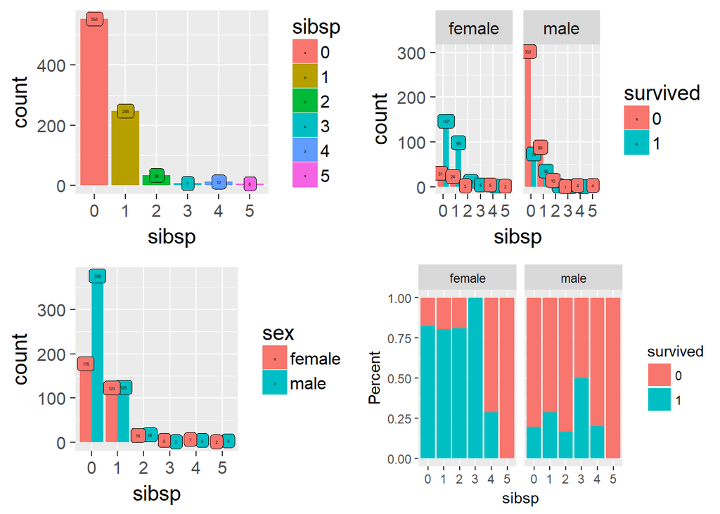

```r
# total statistics
b1 <- ggplot(data, aes(x = sibsp, fill = sibsp)) +
  geom_bar(stat='count', position='dodge') +
  geom_label(stat='count',aes(label=..count..), size=1) +
  theme_grey(base_size = 15)
# statistics showing survival with sex difference
b2 <-
  ggplot(data, aes(x = sibsp, fill = survived)) +
  geom_bar(stat='count', position='dodge') +
  geom_label(stat='count',aes(label=..count..), size=1, position=position_dodge(0.9)) +
  facet_grid(.~sex) +
  theme_grey(base_size = 15)

# total statistics with sex difference
b3 <-
  ggplot(data, aes(x = sibsp, fill = sex)) +
  geom_bar(stat='count', position = 'dodge') +
  geom_label(stat = 'count', aes(label =..count..), size = 1,
             position=position_dodge(0.9))+
  theme_grey(base_size = 15)

# percent statistics showing survival with sex difference
b4 <-
  ggplot(data, aes(x = sibsp, fill = survived)) +
  geom_bar(stat='count', position='fill') +
  labs(x = 'sibsp', y= "Percent") + facet_grid(.~sex) +
  theme(legend.position="none") + theme_grey()

grid.arrange(b1,b2,b3,b4, nrow=2)
```

## 有雙親和小孩的影響

注意: parch為parch為2以前的樣本量較多。

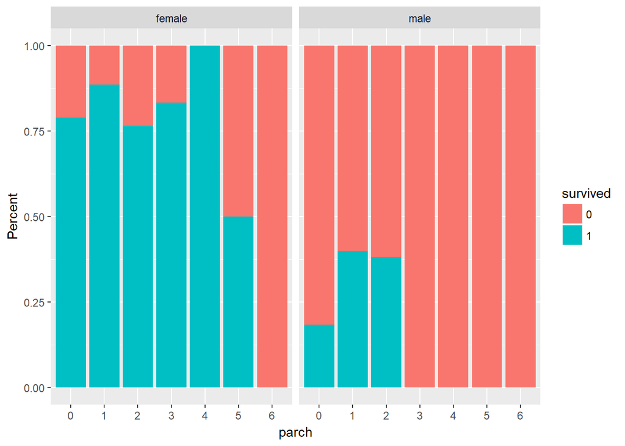

```r
#----- parch-------------

ggplot(data, aes(x = parch, fill = survived)) +
  geom_bar(stat='count', position='fill') +
  labs(x = 'parch', y= "Percent") + facet_grid(.~sex) +
  theme(legend.position="none") + theme_grey()
```

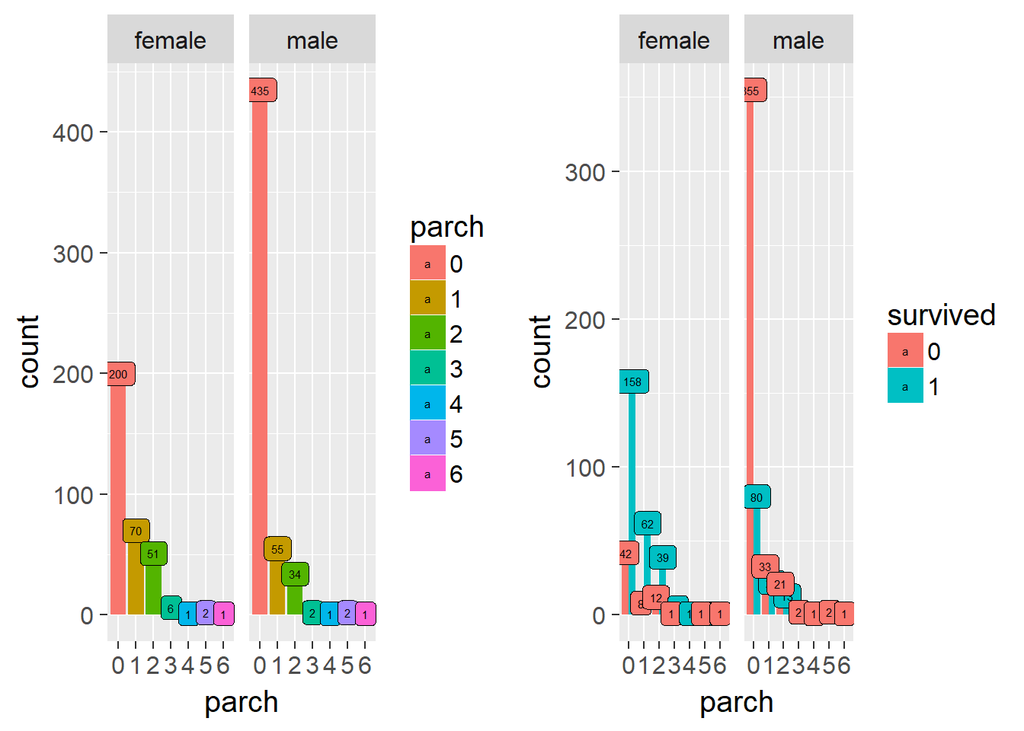

```r
b1 <- ggplot(data, aes(x = parch, fill = parch)) +
  geom_bar(stat='count', position='dodge') +
  facet_grid(.~sex) +
  geom_label(stat='count',aes(label=..count..), size=2) +
  theme_grey(base_size = 15)

b2 <-
  ggplot(data, aes(x = parch, fill = survived)) +
  geom_bar(stat='count', position='dodge') +
  geom_label(stat='count',aes(label=..count..), size=2, position=position_dodge(0.9)) +
  facet_grid(.~sex) +
  theme_grey(base_size = 15)



grid.arrange(b1,b2, nrow=1)
```

## 家庭人數的影響

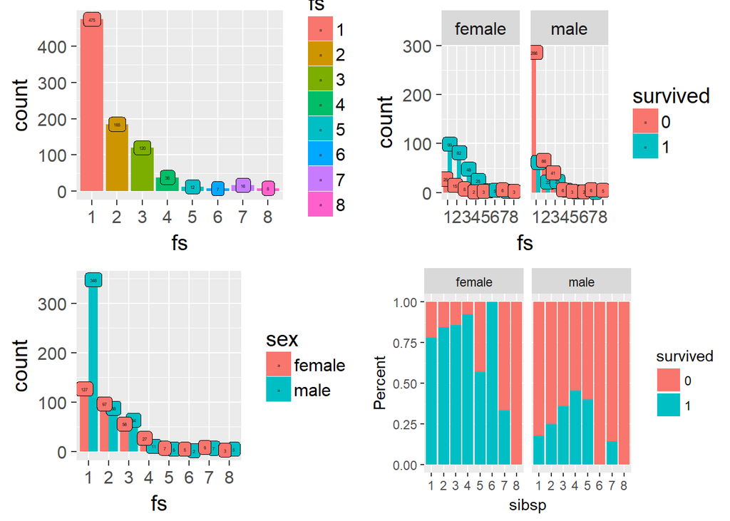

```r
# ------- family size -------

# total statistics
b1 <- ggplot(data, aes(x = fs, fill = fs)) +
  geom_bar(stat='count', position='dodge') +
  geom_label(stat='count',aes(label=..count..), size=1) +
  theme_grey(base_size = 15)
# statistics showing survival with sex difference
b2 <-
  ggplot(data, aes(x = fs, fill = survived)) +
  geom_bar(stat='count', position='dodge') +
  geom_label(stat='count',aes(label=..count..), size=1, position=position_dodge(0.9)) +
  facet_grid(.~sex) +
  theme_grey(base_size = 15)

# total statistics with sex difference
b3 <-
  ggplot(data, aes(x = fs, fill = sex)) +
  geom_bar(stat='count', position = 'dodge') +
  geom_label(stat = 'count', aes(label =..count..), size = 1,
             position=position_dodge(0.9))+
  theme_grey(base_size = 15)

# percent statistics showing survival with sex difference
b4 <-
  ggplot(data, aes(x = fs, fill = survived)) +
  geom_bar(stat='count', position='fill') +
  labs(x = 'sibsp', y= "Percent") + facet_grid(.~sex) +
  theme(legend.position="none") + theme_grey()

grid.arrange(b1,b2,b3,b4, nrow=2)
```

## 年齡

男性存活率最高的在5歲以下 女性則是大部分都存活率極高

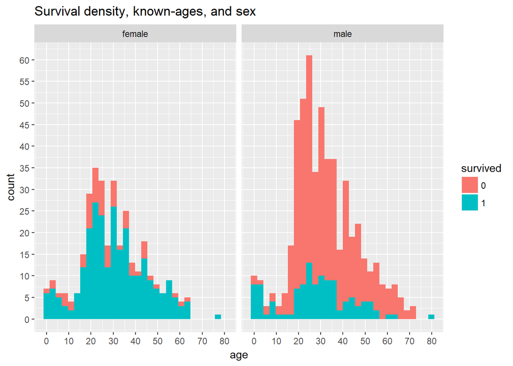

```r
# ------------ age----------
ggplot(data, aes(x = age, fill = survived)) +
  geom_histogram(aes(fill=factor(survived))) + labs(title="Survival density, known-ages, and sex") +
  scale_x_continuous(breaks = scales::pretty_breaks(n = 12)) +
  scale_y_continuous(breaks = scales::pretty_breaks(n = 12)) +
  theme_grey() + facet_grid(.~sex)
```

## 船票票價

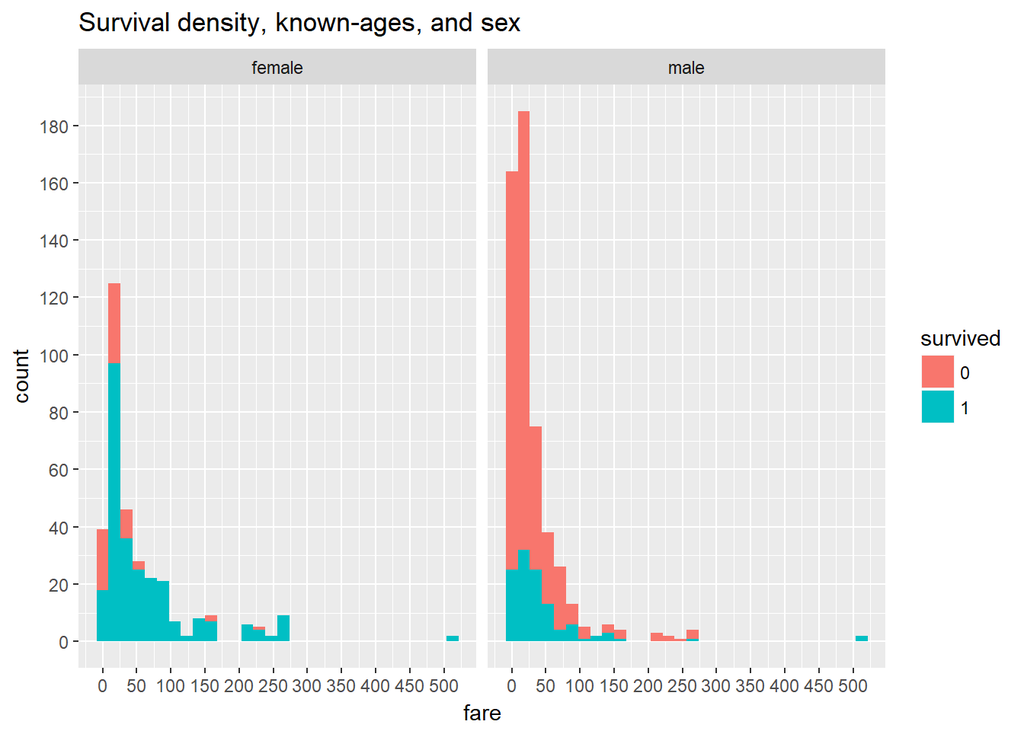

```r
#-------fare--------

ggplot(data, aes(x = fare, fill = survived)) +
  geom_histogram(aes(fill=factor(survived))) + labs(title="Survival density, known-ages, and sex") +
  scale_x_continuous(breaks = scales::pretty_breaks(n = 12)) +
  scale_y_continuous(breaks = scales::pretty_breaks(n = 12)) +
  theme_grey() + facet_grid(.~sex)
```

#兄弟姊妹對存活率的影響

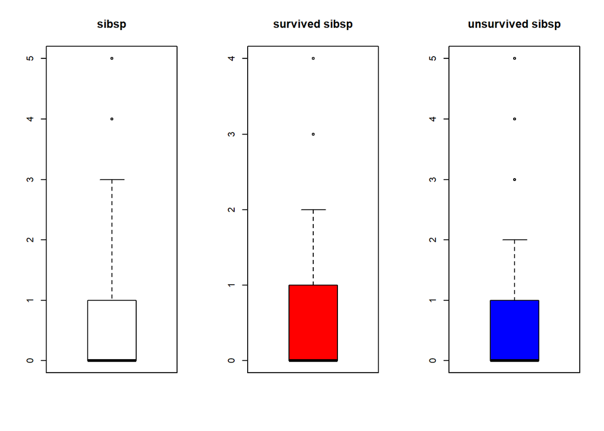

```r
# sibsp的影響
data_sur <- data[data$survived==1, ]
data_un <- data[data$survived==0, ]

par(mfrow=c(1,3))
boxplot(as.numeric(as.character(data$sibsp)), range=2, main="sibsp")
boxplot(as.numeric(as.character(data_sur$sibsp)), col="red", main="survived sibsp")
boxplot(as.numeric(as.character(data_un$sibsp)), col="blue", main="unsurvived sibsp")
```

```r
kable(summary(data_sur$sibsp))
```

|  | x |
| --- | --- |
| 0 | 221 |
| 1 | 135 |
| 2 | 16 |
| 3 | 6 |
| 4 | 3 |
| 5 | 0 |

```r
kable(summary(data_un$sibsp))
```

|  | x |
| --- | --- |
| 0 | 333 |
| 1 | 113 |
| 2 | 18 |
| 3 | 1 |
| 4 | 9 |
| 5 | 6 |

```r
# 存活比例在各兄弟姊妹數量的分布
kable(table(data_sur$sibsp)/length(data_sur$sibsp)*100)
```

| Var1 | Freq |
| --- | --- |
| 0 | 58.0052493 |
| 1 | 35.4330709 |
| 2 | 4.1994751 |
| 3 | 1.5748031 |
| 4 | 0.7874016 |
| 5 | 0.0000000 |

```r
# 死亡比例在各兄弟姊妹數量的分布
kable(table(data_un$sibsp)/length(data_un$sibsp)*100)
```

| Var1 | Freq |
| --- | --- |
| 0 | 69.3750000 |
| 1 | 23.5416667 |
| 2 | 3.7500000 |
| 3 | 0.2083333 |
| 4 | 1.8750000 |
| 5 | 1.2500000 |

```r
# 各兄弟姊妹數量的分布
kable(table(data$sibsp)/length(data$sibsp)*100)
```

[output not shown]

## 年齡和票價

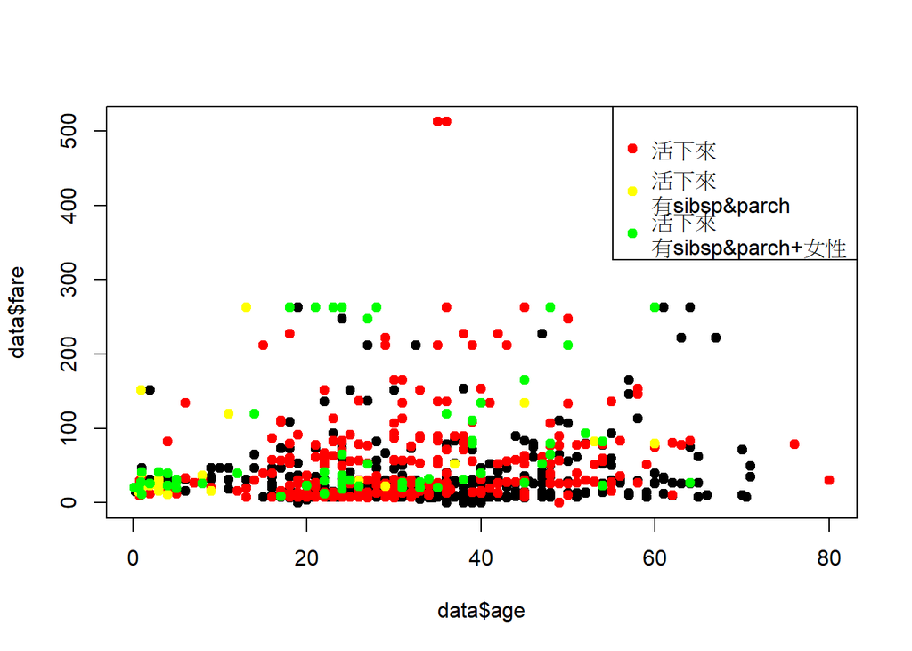

```r
par(pch=19)
plot(data$age, data$fare)
points(data$age[data$survived==1], data$fare[data$survived==1], col="red") #活下
points(data$age[data$survived==1 & data$sibsp!=0 & data$parch!=0],
       data$fare[data$survived==1 & data$sibsp!=0 & data$parch!=0], col="yellow")
points(data$age[data$survived==1 & data$sibsp!=0 & data$parch!=0 & data$sex=="female"], data$fare[data$survived==1 & data$sibsp!=0 & data$parch!=0 & data$sex=="female"],
       col="green")
legend("topright", legend=c("活下來",paste0("活下來","\n","有sibsp&parch"),paste0("活下來","\n","有sibsp&parch+女性")), col=c("red","yellow","green"),pch=19)
```

最高票價的2人都有活下來，但式除了最高票價以外，其實票價的多寡對存活率的影響並會太高

## SVM

```r
library(e1071)

dataas <- subset(data, select=c(pclass,age,sibsp,parch,survived))
dataa <- subset(data, select=c(pclass,age,sibsp,parch))
model <- svm(survived ~ ., data = dataas)
pred_result <- predict(model, dataa)
cm <- table(pred_result, data$survived)
# accuracy
kable((cm[1]+cm[4])/sum(cm)*100)
```

| x |
| --- |
| 68.64111 |

準確率68.6%